# Exercise_15.4

## Exercise 15.4 (From exploration to a rule-based failure model)

1. Translate the thresholds from Milestone 2 and/or 3 into explicit rules: write one Python function per failure type that predicts whether a sample fails.
2. Evaluate your rules against the labels: compute the confusion matrix for each failure type.
3. Train a shallow decision tree per failure type. Compare the trees and your hand-crafted rules. Which one would you rather explain to a process engineer?
1. Translate the thresholds from Milestone 2 and/or 3 into explicit rules: write one Python function per failure type that predicts whether a sample fails.
2. Evaluate your rules against the labels: compute the confusion matrix for each failure type.

```python
import pandas as pd
import matplotlib.pyplot as plt
import sklearn.tree as skt
from sklearn.metrics import confusion_matrix, ConfusionMatrixDisplay

df = pd.read_csv("XAI_Drilling_Dataset.csv")

failure_cols = ["BEF", "CCF", "FWF", "WDF"]

df.head()
```

|  | ID | Cutting speed vc [m/min] | Spindle speed n [1/min] | Feed f [mm/rev] | Feed rate vf [mm/min] | Power Pc [kW] | Cooling [%] | Material | Drill Bit Type | Process Time [sec] | Main Failure | BEF | CCF | FWF | WDF |
| --- | --- | --- | --- | --- | --- | --- | --- | --- | --- | --- | --- | --- | --- | --- | --- |
| 0 | 1 | 29.92 | 794 | 0.218 | 173 | 194.87 | 75 | N | W | 19.26 | 0 | 0 | 0 | 0 | 0 |
| 1 | 2 | 29.85 | 792 | 0.241 | 191 | 214.71 | 75 | N | W | 19.55 | 0 | 0 | 0 | 0 | 0 |
| 2 | 3 | 22.85 | 606 | 0.183 | 111 | 95.68 | 50 | P | N | 36.16 | 0 | 0 | 0 | 0 | 0 |
| 3 | 4 | 29.60 | 785 | 0.236 | 237 | 206.93 | 75 | N | W | 21.22 | 1 | 0 | 0 | 1 | 0 |
| 4 | 5 | 17.43 | 462 | 0.246 | 114 | 74.85 | 50 | K | H | 33.56 | 0 | 0 | 0 | 0 | 0 |

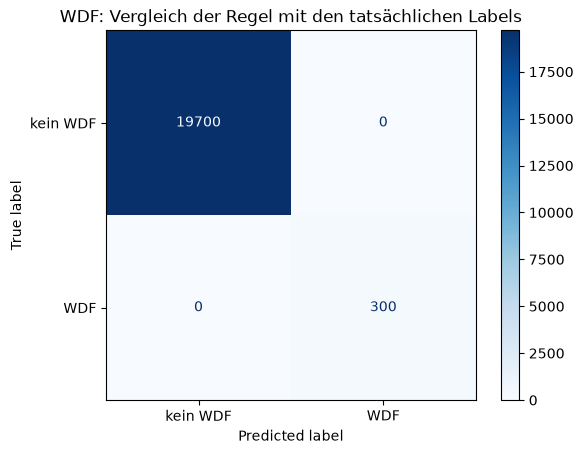

```python
# WDF vorhersagen
def predict_wdf(row):
    correct_drill = {
        "K": "H",       # Bei Material K ist der korrekte Bohrertyp H
        "P": "N",       # Bei Material P ist der korrekte Bohrertyp N
        "N": "W"        # Bei Material N ist der korrekte Bohrertyp W
    }

    return int(
        row["Drill Bit Type"] != correct_drill[row["Material"]]
    )


df["WDF_pred"] = df.apply(predict_wdf, axis=1)  # Berechne die Vorhersagen für WDF und speichere sie in einer neuen Spalte


# Anwenden der Regel
cm = confusion_matrix(
    df["WDF"],
    df["WDF_pred"],
    labels=[0, 1]
)

ConfusionMatrixDisplay(
    confusion_matrix=cm,
    display_labels=["kein WDF", "WDF"]
).plot(cmap="Blues", values_format="d")

plt.title("WDF: Vergleich der Regel mit den tatsächlichen Labels")
plt.show()
```

Die WDF-Regel klassifiziert alle Beobachtungen des untersuchten Datensatzes korrekt. Alle 300 WDF-Fälle werden erkannt und alle 19.700 Beobachtungen ohne WDF richtig eingeordnet. Es entstehen weder Fehlalarme noch übersehene Fehler. Die Abweichung von den passenden Material-Bohrer-Kombinationen K–H, P–N und N–W bildet die WDF-Kennzeichnung in diesem Datensatz vollständig ab.

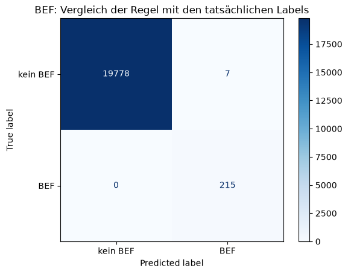

```python
# BEF vorhersagen
def predict_bef(row):
    low_cutting_speed = (
        (row["Material"] == "K"
         and row["Cutting speed vc [m/min]"] <= 16.7)       # Geringe Schnittgeschwindigkeit (≤ 16,7 m/min für Material K) führt zu BEF
        or
        (row["Material"] == "P"
         and row["Cutting speed vc [m/min]"] <= 22)         # Geringe Schnittgeschwindigkeit (≤ 22 m/min für Material P) führt zu BEF
    )

    low_cooling = row["Cooling [%]"] <= 25                  # Geringe Kühlung (≤ 25%) führt zu BEF

    return int(low_cutting_speed and low_cooling)


df["BEF_pred"] = df.apply(predict_bef, axis=1)


# Anwenden der Regel
cm = confusion_matrix(
    df["BEF"],
    df["BEF_pred"],
    labels=[0, 1]
)

ConfusionMatrixDisplay(
    confusion_matrix=cm,
    display_labels=["kein BEF", "BEF"]
).plot(cmap="Blues", values_format="d")

plt.title("BEF: Vergleich der Regel mit den tatsächlichen Labels")
plt.show()
```

Die BEF-Regel erkennt alle 215 tatsächlichen Fehlerfälle. Zusätzlich werden sieben Beobachtungen ohne BEF fälschlich als Fehler eingestuft. Die übrigen 19.778 Beobachtungen ohne BEF werden korrekt erkannt.

Die aus den Diagrammen abgeleitete Kombination aus materialspezifischer Schnittgeschwindigkeitsgrenze und geringer Kühlung bildet die Fehlerkennzeichnung damit nahezu vollständig ab. Die gewählten Grenzen sind jedoch etwas zu weit gefasst, da sieben Fehlalarme entstehen.

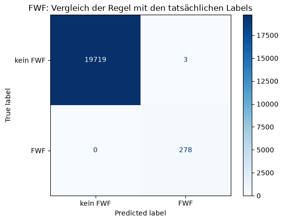

```python
# FWF vorhersagen
def predict_fwf(row):
    # Definiere die Grenzwerte für Schnittgeschwindigkeit und Vorschubrate basierend auf dem Material
    limits = {
        "K": (16.7, 149),
        "P": (22.0, 127),
        "N": (29.7, 206)
    }

    cutting_limit, feed_limit = limits[row["Material"]]

    return int(
        row["Cutting speed vc [m/min]"] <= cutting_limit    # Geringe Schnittgeschwindigkeit (≤ Grenzwert für das jeweilige Material) führt zu FWF
        and row["Feed rate vf [mm/min]"] >= feed_limit      # Hohe Vorschubrate (≥ Grenzwert für das jeweilige Material) führt zu FWF
    )


df["FWF_pred"] = df.apply(predict_fwf, axis=1)


# Anwenden der Regel
cm = confusion_matrix(
    df["FWF"],
    df["FWF_pred"],
    labels=[0, 1]
)

ConfusionMatrixDisplay(
    confusion_matrix=cm,
    display_labels=["kein FWF", "FWF"]
).plot(cmap="Blues", values_format="d")

plt.title("FWF: Vergleich der Regel mit den tatsächlichen Labels")
plt.show()
```

Die FWF-Regel erkennt alle 278 tatsächlichen Fehlerfälle. Drei Beobachtungen ohne FWF werden fälschlich als Fehler eingestuft, während die übrigen 19.719 korrekt erkannt werden.

Die Kombination aus materialspezifischer oberer Schnittgeschwindigkeitsgrenze und unterer Vorschubgrenze bildet die Fehlerkennzeichnung im untersuchten Datensatz nahezu vollständig ab. Es entstehen keine übersehenen Fehler, aber drei Fehlalarme. Die Bewertung erfolgt auf denselben Daten, aus denen die Grenzen abgeleitet wurden.

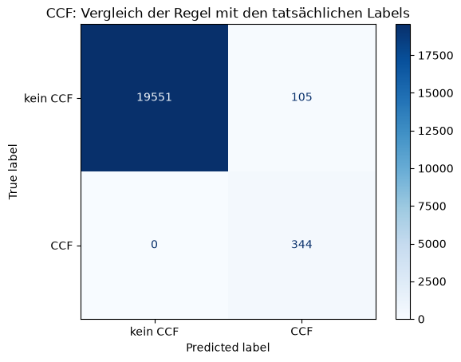

```python
# CCNF vorhersagen
def predict_ccf(row):
    # Definiere die Grenzwerte für Vorschubrate basierend auf dem Material
    feed_limits = {
        "K": 125,
        "P": 120,
        "N": 205
    }

    # Definiere die korrekten Bohrertypen basierend auf dem Material
    correct_drill = {
        "K": "H",
        "P": "N",
        "N": "W"
    }

    # Überprüfe die Bedingungen für CCF
    high_feed = (
        row["Feed rate vf [mm/min]"] >= feed_limits[row["Material"]]
    )

    low_cooling = row["Cooling [%]"] <= 25

    wrong_drill = (
        row["Drill Bit Type"] != correct_drill[row["Material"]]
    )

    conditions_met = sum([high_feed, low_cooling, wrong_drill])

    return int(conditions_met >= 2)


df["CCF_pred"] = df.apply(predict_ccf, axis=1)


# Anwenden der Regel
cm = confusion_matrix(
    df["CCF"],
    df["CCF_pred"],
    labels=[0, 1]
)

ConfusionMatrixDisplay(
    confusion_matrix=cm,
    display_labels=["kein CCF", "CCF"]
).plot(cmap="Blues", values_format="d")

plt.title("CCF: Vergleich der Regel mit den tatsächlichen Labels")
plt.show()
```

Die CCF-Regel erkennt alle 344 tatsächlichen Fehlerfälle. Zusätzlich werden 105 Beobachtungen ohne CCF fälschlich als Fehler eingestuft. Die übrigen 19.551 Beobachtungen ohne CCF werden korrekt erkannt.

Die Kombination aus mindestens zwei der drei Bedingungen – hohe Vorschubgeschwindigkeit, geringe Kühlung und ungeeigneter Bohrer – erfasst somit sämtliche CCF-Fälle. Die gewählten Schwellenwerte grenzen die Fehlerfälle jedoch noch nicht ausreichend von den übrigen Beobachtungen ab. Die Bewertung erfolgt auf demselben Datensatz, aus dem die Regeln abgeleitet wurden.

3. Train a shallow decision tree per failure type. Compare the trees and your hand-crafted rules. Which one would you rather explain to a process engineer?

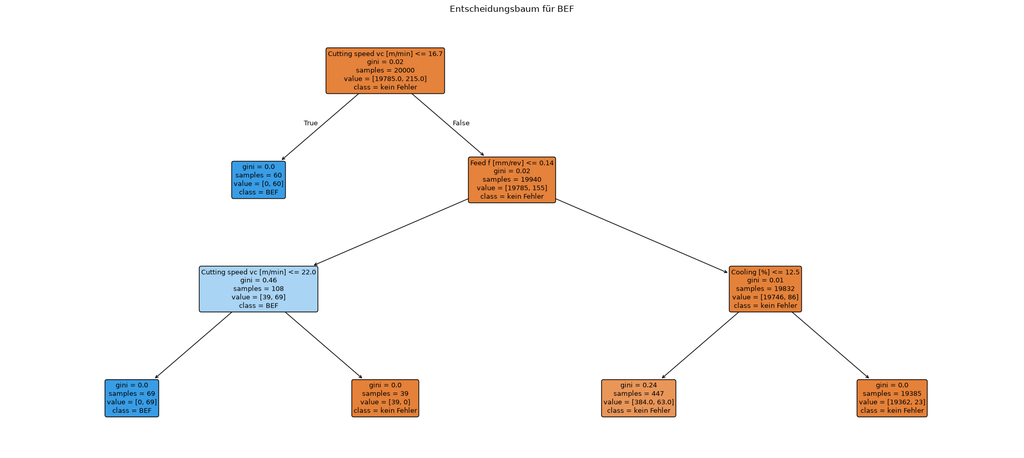

```
BEF: tatsächliche Baumtiefe = 3
```

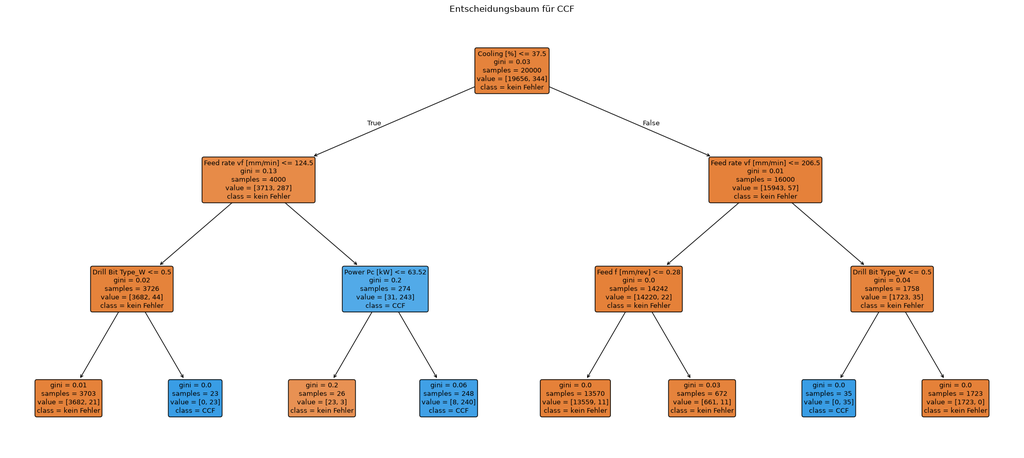

```
CCF: tatsächliche Baumtiefe = 3
```

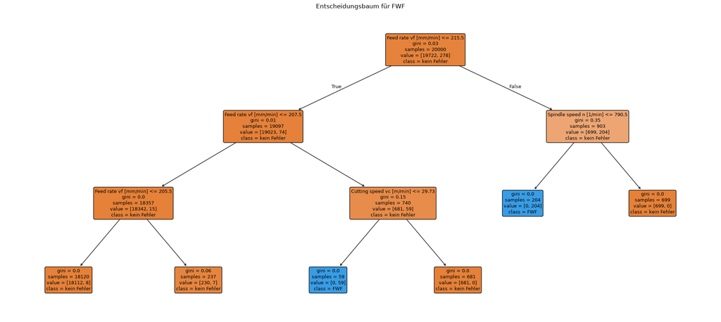

```
FWF: tatsächliche Baumtiefe = 3
```

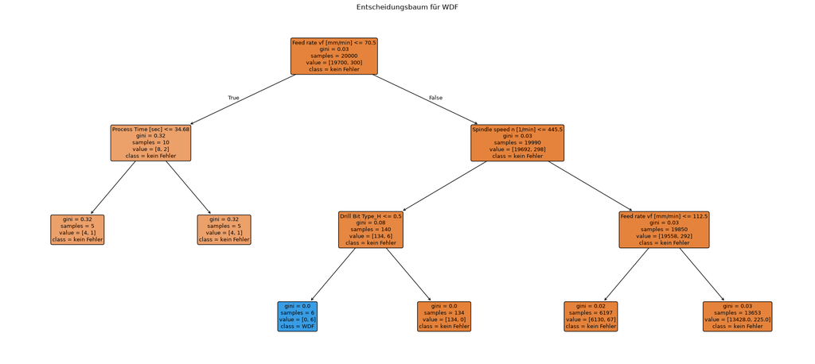

```
WDF: tatsächliche Baumtiefe = 3
```

|  | Fehlerart | Methode | Richtig ohne Fehler | Fehlalarme | Übersehene Fehler | Erkannte Fehler |
| --- | --- | --- | --- | --- | --- | --- |
| 0 | BEF | Regel | 19778 | 7 | 0 | 215 |
| 1 | BEF | Entscheidungsbaum | 19785 | 0 | 86 | 129 |
| 2 | CCF | Regel | 19551 | 105 | 0 | 344 |
| 3 | CCF | Entscheidungsbaum | 19648 | 8 | 46 | 298 |
| 4 | FWF | Regel | 19719 | 3 | 0 | 278 |
| 5 | FWF | Entscheidungsbaum | 19722 | 0 | 15 | 263 |
| 6 | WDF | Regel | 19700 | 0 | 0 | 300 |
| 7 | WDF | Entscheidungsbaum | 19700 | 0 | 294 | 6 |

```python
# Eingabemerkmale vorbereiten
features = [
    "Cutting speed vc [m/min]",
    "Spindle speed n [1/min]",
    "Feed f [mm/rev]",
    "Feed rate vf [mm/min]",
    "Power Pc [kW]",
    "Cooling [%]",
    "Process Time [sec]",
    "Material",
    "Drill Bit Type"
]

# Erstelle Dummy-Variablen für die kategorischen Merkmale Material und Drill Bit Type
X = pd.get_dummies(
    df[features],
    columns=["Material", "Drill Bit Type"],
    dtype=int
)

# Trainiere Entscheidungsbäume für jede Fehlerart und vergleiche die Ergebnisse mit den Regeln
failure_cols = ["BEF", "CCF", "FWF", "WDF"]
results = []

for failure in failure_cols:
    y = df[failure]

    tree = skt.DecisionTreeClassifier(
        max_depth=3,            # Maximale Tefe des Baums
        random_state=42,
        min_samples_split=5,    # Minimale Anzahl von Samples, die benötigt werden, um einen Knoten zu teilen
        min_samples_leaf=5      # Minimale Anzahl von Samples, die in einem Blattknoten benötigt werden
    )

    tree.fit(X, y)                      # Trainiere den Entscheidungsbaum mit den Eingabemerkmalen X und den Zielvariablen y
    tree_prediction = tree.predict(X)   # Vorhersagen des Entscheidungsbaums für die Eingabemerkmale X

    # Visualisiere den Entscheidungsbaum
    plt.figure(figsize=(20, 9))

    skt.plot_tree(
        tree,
        feature_names=X.columns.tolist(),
        class_names=["kein Fehler", failure],
        filled=True,
        rounded=True,
        fontsize=9,
        precision=2
    )

    plt.title(f"Entscheidungsbaum für {failure}")
    plt.tight_layout()
    plt.show()

    print(f"{failure}: tatsächliche Baumtiefe = {tree.get_depth()}")

    predictions = {
        "Regel": df[f"{failure}_pred"],
        "Entscheidungsbaum": tree_prediction
    }

    for method, prediction in predictions.items():
        tn, fp, fn, tp = confusion_matrix(
            y,
            prediction,
            labels=[0, 1]
        ).ravel()

        results.append({
            "Fehlerart": failure,
            "Methode": method,
            "Richtig ohne Fehler": tn,
            "Fehlalarme": fp,
            "Übersehene Fehler": fn,
            "Erkannte Fehler": tp
        })

results = pd.DataFrame(results)
display(results)
```

### Vergleich der Regeln mit Entscheidungsbäumen

Für jede Fehlerart wurde ein Entscheidungsbaum mit maximaler Tiefe 3 trainiert. Die Bewertung erfolgte auf demselben Datensatz wie die Bewertung der selbst formulierten Regeln.

Bei BEF erkennt die Regel alle 215 Fehlerfälle mit sieben Fehlalarmen. Der Baum erzeugt keine Fehlalarme, übersieht jedoch 86 Fehlerfälle. Bei FWF erkennt die Regel ebenfalls alle Fehlerfälle und verursacht drei Fehlalarme. Der Baum übersieht dagegen 15 Fälle.

Bei CCF reduziert der Baum die Fehlalarme von 105 auf acht, übersieht dafür aber 46 Fehlerfälle. Welche Lösung vorzuziehen ist, hängt deshalb davon ab, wie schwer Fehlalarme gegenüber übersehenen Fehlern wiegen.

Der größte Unterschied zeigt sich bei WDF. Die Zuordnungsregel klassifiziert alle Beobachtungen korrekt, während der Baum nur sechs der 300 Fehlerfälle erkennt. Die Beziehung zwischen Material und passendem Bohrertyp wird von diesem flachen Baum nicht ausreichend erfasst.

Einem Prozessingenieur würde ich bevorzugt die selbst formulierten Regeln erklären. Sie beziehen sich unmittelbar auf verständliche Prozessbedingungen und Material-Bohrer-Zuordnungen. Besonders die WDF-Regel ist einfacher und genauer als der gelernte Baum. Die CCF-Regel sollte wegen ihrer vielen Fehlalarme jedoch weiter geprüft werden.

Die Ergebnisse beschreiben die Anpassung an den vorhandenen Datensatz. Da dieser auch zur Ableitung der Regeln und zum Training der Bäume verwendet wurde, ist damit noch keine Vorhersagequalität für neue Daten nachgewiesen.

HTML erstellt mit:

uv run jupyter nbconvert --to html -- "Tasks/15 Self study - Session 2/Exercise_15.4.ipynb"